# Uso de xtabs()

Jose Manuel Valdeolmillos

13 de mayo de 2016

## Introduccion:

Uso de xtabs() para crear tablas de contingecia.

## Carga de datos.

Primero cargamos los datos y posteriormente se muestra por pantalla el dataFrame formateado:

```r
Data1 <- data.frame(Reference = c("KRXH", "KRPT", "FHRA", "CZKK", "CQTN", "PZXW", "SZRZ", "RMZE", "STNX", "TMDW"), Status = c("Accepted", "Accepted", "Rejected", "Accepted", "Rejected", "Accepted", "Rejected", "Rejected", "Accepted", "Accepted"), Gender = c("Female", "Male", "Male", "Female", "Female", "Female", "Male", "Female", "Female", "Female"), Test = c("Test1", "Test1", "Test2", "Test3", "Test1", "Test4", "Test4", "Test2", "Test3", "Test1"), NewOrFollowUp = c("New", "New", "New", "New", "New", "Follow-up", "New", "New", "New", "New"))


# Visualizacion
head(Data1)
```

```
##   Reference   Status Gender  Test NewOrFollowUp
## 1      KRXH Accepted Female Test1           New
## 2      KRPT Accepted   Male Test1           New
## 3      FHRA Rejected   Male Test2           New
## 4      CZKK Accepted Female Test3           New
## 5      CQTN Rejected Female Test1           New
## 6      PZXW Accepted Female Test4     Follow-up
```

## Ejercicio 1 - Mostrar conteo de Status.

The xtabs() function can display the frequency, or count, of the levels of categorical variables. For the first exercise, use the xtabs() function to find the count of levels in the variable, “Status“, within the above dataframe, “Data1“.

```r
xtabs(~Status, data = Data1)
```

```
## Status
## Accepted Rejected
##        6        4
```

## Ejercicio 2 - Descubrir relacion entre 2 variables.

Next, using the xtabs() function, apply two variables from “Data1“, to create a table delineating the relationship between the “Reference” category, and the “Status” category.

```r
xtabs(~Reference + Status, data = Data1)
```

```
##          Status
## Reference Accepted Rejected
##      CQTN        0        1
##      CZKK        1        0
##      FHRA        0        1
##      KRPT        1        0
##      KRXH        1        0
##      PZXW        1        0
##      RMZE        0        1
##      STNX        1        0
##      SZRZ        0        1
##      TMDW        1        0
```

## Ejercicio 3 - Descubrir relacion entre 3 variables o categorias

Apply three variables from “Data1” to create a Multi-Dimensional Cross-Tabulation of “Status“, “Gender“, and “Test“.

```r
xtabs(~Status + Gender + Test, data = Data1)
```

```
## , , Test = Test1
##
##           Gender
## Status     Female Male
##   Accepted      2    1
##   Rejected      1    0
##
## , , Test = Test2
##
##           Gender
## Status     Female Male
##   Accepted      0    0
##   Rejected      1    1
##
## , , Test = Test3
##
##           Gender
## Status     Female Male
##   Accepted      2    0
##   Rejected      0    0
##
## , , Test = Test4
##
##           Gender
## Status     Female Male
##   Accepted      1    0
##   Rejected      0    1
```

## Ejercicio 4 - Creating 2 Dimensional tables from Multi-Dimensional

Enclose the xtabs() formula from Exercise 3 within the “ftable()” function, to display a Multi-Dimensional Cross-Tabulation in two dimensions.

```r
ftable(xtabs(~Status + Gender + Test, data = Data1))
```

```
##                 Test Test1 Test2 Test3 Test4
## Status   Gender
## Accepted Female          2     0     2     1
##          Male            1     0     0     0
## Rejected Female          1     1     0     0
##          Male            0     1     0     1
```

## Ejercicio 5 - Filas como porcentajes

Con tigerstats sacamos varias estadisticas.

1. Create an xtabs() formula that cross-tabulates “Status“, and “Test“.
2. Enclose the xtabs() formula in the tigerstats function, “rowPerc()” to display row percentages for “Status” by “Test“.

```r
if(!require(tigerstats)) {install.packages("tigerstats"); require(tigerstats)}
library(tigerstats)
```

```r
rowPerc(xtabs(~Status + Test, data = Data1))
```

```
##           Test
## Status      Test1  Test2  Test3  Test4  Total
##   Accepted  50.00   0.00  33.33  16.67 100.00
##   Rejected  25.00  50.00   0.00  25.00 100.00
```

## Ejercicio 6 - Columnas como porcentajes

1. Create an xtab() formula that cross-tabulates “Reference“, and “Status“.
2. Use “colPerc()” to display column percentages for “Reference” by “Status“.

```r
colPerc(xtabs(~Reference + Status, data = Data1))
```

```
##          Status
## Reference Accepted Rejected
##     CQTN      0.00       25
##     CZKK     16.67        0
##     FHRA      0.00       25
##     KRPT     16.67        0
##     KRXH     16.67        0
##     PZXW     16.67        0
##     RMZE      0.00       25
##     STNX     16.67        0
##     SZRZ      0.00       25
##     TMDW     16.67        0
##     Total   100.00      100
```

## Ejercicio 7 - Plotting Cross-Tabulations

Use the “plot()” function, and the “xtabs()” function to plot “Status” by “Gender“.

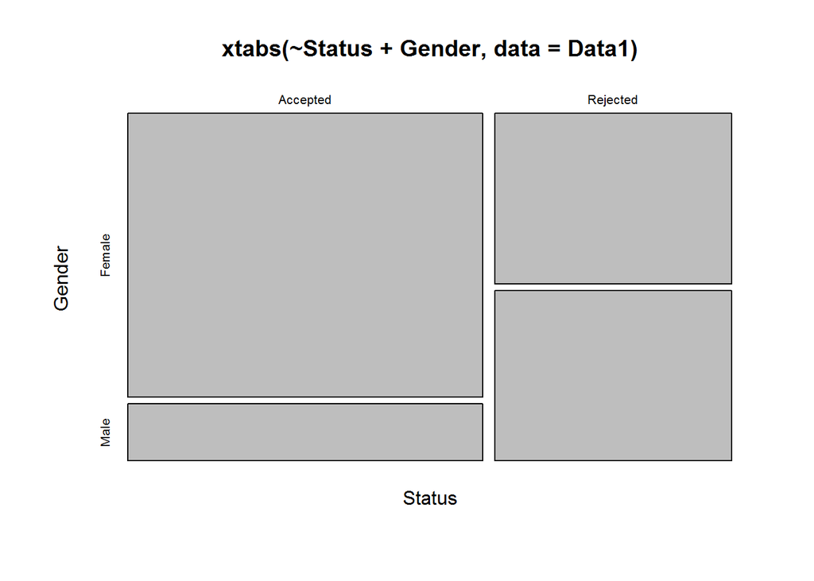

```r
plot(xtabs(~Status + Gender, data = Data1))
```

## Ejercicio 8 - La variable explicativa afecta a la variable respuesta?

In order to examine whether the explanatory variable “Gender” affects the response variable “ Status“, create a two factor xtabs() formula with the Response variable as the first condition, and the Explanatory variable as the second condition.

```r
xtabs(~Status + Gender, data = Data1)
```

```
##           Gender
## Status     Female Male
##   Accepted      5    1
##   Rejected      2    2
```

## Ejercicio 9 - Uso de cbind() con xtabs()

Delante de ~ con cbind() para sacar más de una columna. Las variables de las filas se ponen después del ~ Using the “cbind()” function within an xtabs() formula can define the last two columns of a flat table of your dataset. The variable after ~ (tilde) will display as the row data. For example, ftable(xtabs(cbind(variable1, variable2) ~ variable3, data=" “)).

For this exercise, create a flat table with columns for “Gender” and “Test“. The row variables are “Reference“.

```r
ftable(xtabs(cbind(Gender, Test) ~ Reference, data=Data1))
```

```
##            Gender Test
## Reference
## CQTN            1    1
## CZKK            1    3
## FHRA            2    2
## KRPT            2    1
## KRXH            1    1
## PZXW            1    4
## RMZE            1    2
## STNX            1    3
## SZRZ            2    4
## TMDW            1    1
```

## Ejercicio 10 - Testeando Correlaciones con xtabs()

When processed through the “summary()” function, an xtabs() formula can test for independence of variables. Therefore, use summary() and xtabs() to test for a “Reference” affecting “Status” correlation.

```r
summary(xtabs(~Reference + Status, data=Data1))
```

```
## Call: xtabs(formula = ~Reference + Status, data = Data1)
## Number of cases in table: 10
## Number of factors: 2
## Test for independence of all factors:
##  Chisq = 10, df = 9, p-value = 0.3505
##  Chi-squared approximation may be incorrect
```